# PandemicLP

```r
library(PandemicLP)
```

In this vignette, we present the main functionality of the PandemicLP package. The package uses the theory presented in http://est.ufmg.br/covidlp/home/pt/. As the model evolves, new versions of the package are released. This vignette, however, aims to only show the five basic functions of the package.

## Loading data

Function `load_covid()` loads Covid-19 data from online repositories. The first argument is a string with the country’s name. Use `country_list()` for a complete list of possibilities. The second argument is another string with the state’s name *if* the country is “Brazil”. Use `state_list()` for a similar list. Finally, you can use the last_date argument if you don’t want to use all the data and compare the predictions with updated data. After loading the data using `load_covid()`, it can be plotted using the `plot` generic function.

```r
MGdata = load_covid("Brazil","MG")
plot(MGdata)$new
```

```
#> Plotting Data
#> The generated plot(s) can be stored in a variable.
#> New Cases plot: variable$new
#> Warning: `arrange_()` is deprecated as of dplyr 0.7.0.
#> Please use `arrange()` instead.
#> See vignette('programming') for more help
```

[interactive chart not shown]

External data can also be loaded and estimated using the package. For that purpose, it needs to be put in an adequate format. Please read `help("covid19BH")` for an example of using external data to fit and predict one of the package models.

## Estimating model

The model is estimated with function `pandemic_model`. It currently uses rstan to draw samples from the posterior distribution. The first argument can be either the output of the `load_covid()` function or a list with the proper elements. Customized control of the stan algorithm can be also set in this function. You can choose to fit the ‘confirmed’ or ‘deaths’ series. Use the option `covidLPconfig = TRUE` to use the same configuration of the app in https://dest-ufmg.shinyapps.io/app_COVID19/.

```r
# Commenting to reduce vignette runtime
# MGestimated = pandemic_model(MGdata, case_type = "deaths", covidLPconfig = TRUE)
# Load precomputed MCMC
download.file("http://github.com/CovidLP/PandemicLP/raw/master/temp/PandemicLP.rda","./PandemicLP.rda")
load("./PandemicLP.rda")
```

By calling the output of the function, a small summary of the estimation is given.

```r
MGestimated
```

```
#> pandemic_model
#>  Distribution:        poisson
#>  Mean function form:  static generalized logistic
#>  Type of Case:        deaths
#>  Location:            Brazil_MG
#>  0bservations:        275
#>
#> ------
#> Parameters:
#>    mean  2.5%   50% 97.5%   n_eff  Rhat
#> a 0.747 0.394 0.721 1.305 696.147 1.000
#> b 0.056 0.037 0.055 0.083 516.922 1.003
#> c 0.023 0.021 0.023 0.024 538.510 1.005
#> f 3.350 2.749 3.310 4.105 540.332 1.002
#>
#> ------
#> Priors:
#>
#>  a  ~  Gamma(0.1, 0.1)
#>  b  ~  LogNormal(0, 20)
#>  c  ~  Gamma(2, 9)
#>  f  ~  Gamma(0.01, 0.01)
#>
#> Restrictions:
#>  1:  a/b^f < 0.02 *population
#>  2:  f > 1
#>
#> ------
#> *For help interpreting the printed output see ?print.pandemicEstimated
#> *For more information see ?'summary.pandemicEstimated
#> *For details on the model, priors and restrictions, see the Details section in ?pandemic_model
```

Convergence diagnostics can be used on the ‘fit’ element of the output. In particular, the relevant parameters are ‘a’, ‘b’, ‘c’ and ‘f’.

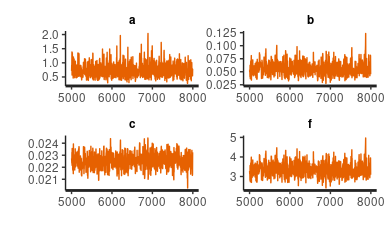

```r
traceplot(MGestimated)+theme(legend.position = "")
```

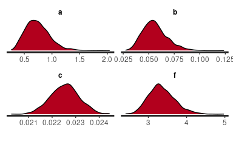

```r
density(MGestimated)
```

Note: `traceplot` can be used directly on the output, without a reference to the ‘fit’ element nor the parameters.

## Prediction

In order to make the predictions using the model fitted from `pandemic_model`, use the `rstantools::posterior_predict` generic function. Also, set custom prediction horizons with options `horizonLong` and `horizonShort`. The difference is that the long term prediction uses daily predictions and the short term uses accumulated predictions.

```r
MGpredicted = posterior_predict(MGestimated,horizonLong=200)
MGpredicted
```

```
#>
#> Predicted pandemic death cases for Brazil_MG. Can be plotted with plot().
#>
#> Showing predictive stats::median for the long-term predictions for Brazil_MG.
#>
#> 2020-11-26 2020-11-27 2020-11-28
#>         25         25         25
#>    ...
#>
#> 2021-06-11 2021-06-12 2021-06-13
#>          0          0          0
#>
#> *For customized view, see help(print.pandemicPredicted)
#> **For more details, see help(pandemicPredicted-xs)
```

The output can also be printed for a small summary. Note that the full predictive distribution sample is returned in this function.

## Useful statistics

Some useful statistics from the [CovidLP](http://est.ufmg.br/covidlp/home/pt/) app have been programmed into a function. Use this function to obtain short and long term predictions, predicted total number of cases, predicted peak date and the date when the pandemic is predicted to end.

```r
pandemic_stats(MGpredicted)
```

```
#>
#> 95% Credible Intervals for death cases in Brazil_MG
#>
#> Short-term Predictions:
#>         date      q2.5       med     q97.5      mean
#> 1 2020-11-26  9874.000      9883  9895.025  9883.805
#> 2 2020-11-27  9895.975      9909  9925.000  9909.008
#> 3 2020-11-28  9918.000      9934  9953.000  9934.197
#>    ...
#> 12 2020-12-07 10100.975     10138 10179.000 10137.982
#> 13 2020-12-08 10119.000     10159 10203.000 10158.423
#> 14 2020-12-09 10135.000     10178 10223.000 10178.501
#>
#> ------
#> Long-term Predictions:
#>         date              q2.5               med             q97.5
#> 1 2020-11-26            16.000                25            37.025
#> 2 2020-11-27            16.000                25            36.000
#> 3 2020-11-28            16.000                25            36.000
#>                mean
#> 1            25.805
#> 2            25.203
#> 3            25.189
#>    ...
#> 198 2021-06-11            0.000                0            2.000
#> 199 2021-06-12            0.000                0            2.000
#> 200 2021-06-13            0.000                0            2.000
#>
#> 198            0.356
#> 199            0.339
#> 200            0.336
#>
#> ------
#> Total Number of Cases:
#>     q2.5   med    q97.5
#>  10394.9 11058 12161.27
#>
#> ------
#> Peak Dates:
#>        q2.5        med      q97.5
#>  2020-08-08 2020-08-24 2020-09-11
#>
#> ------
#> End Dates:
#>        q2.5        med      q97.5
#>  2021-03-08 2021-03-16 2021-03-26
#>
#> ------
#> *Use plot() to see these statistics in a graph format.
#> *For more information, see ?'pandemicStats-xs'.
#> *For details on the calculations, see ?pandemic_stats.
```

## Plotting

Generic function `plot` can be used on the prediction to plot the predictions using the `plotly` package, whose figure is interactive. Up to two plots are outputted, which can be stored for later use.

```r
MGplots = plot(MGpredicted,term="both")
```

```
#> Plotting deaths cases
#> Short term plot created successfully
#> Long term plot created successfully
#> The generated plot(s) can be stored in a variable.
#> Long term plot: variable$long
#> Short term plot: variable$short
```

```r
MGplots$long
```

[interactive chart not shown]

```r
MGplots$short
```

[interactive chart not shown]